# Correlations between fat and organics - Norwegian cod

DHJ

25 11 2020

## Example: one substance (BDE49), one station (30B)

Model: `ln(concentration) = a*ln(fat) + b*Length + spline(Year)`

Thus:

- The effect of ln(fat) assumed to be linear
- Effect of year (non-linear effect) and length (linear) also taken into account

In the output and plot below,  
* MYEAR = measurement year  
* FAT_PERC = fat percentage in tissue  
* LNMEA = length of fish in millimeters

```
##
## Family: gaussian
## Link function: identity
##
## Formula:
## log(VALUE_WW) ~ s(MYEAR) + log(FAT_PERC) + LNMEA
##
## Parametric coefficients:
##                 Estimate Std. Error t value Pr(>|t|)
## (Intercept)   -3.5859669  0.3950471  -9.077  < 2e-16 ***
## log(FAT_PERC)  1.1314555  0.1046854  10.808  < 2e-16 ***
## LNMEA          0.0015137  0.0005478   2.763  0.00626 **
## ---
## Signif. codes:  0 '***' 0.001 '**' 0.01 '*' 0.05 '.' 0.1 ' ' 1
##
## Approximate significance of smooth terms:
##            edf Ref.df     F p-value
## s(MYEAR) 2.153  2.579 5.405 0.00326 **
## ---
## Signif. codes:  0 '***' 0.001 '**' 0.01 '*' 0.05 '.' 0.1 ' ' 1
##
## R-sq.(adj) =  0.447   Deviance explained = 45.8%
## GCV = 0.66053  Scale est. = 0.64401   n = 206
```

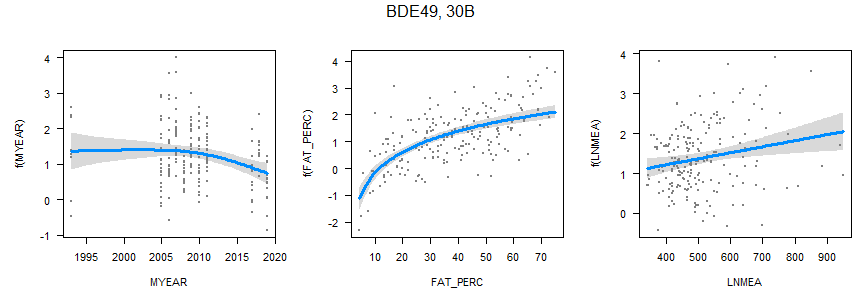

### Several substances + stations

## Effect of fat, slope

Effect of ln(fat) on ln(concentration)

- Analysis on station-by-station basis
- The effect of ln(fat) assumed to be linear
- Effect of year (non-linear effct) and length (linear) also taken into account
- Analysis done for time series with at least 10 years and at least 70% data over LOQ

### PCBs

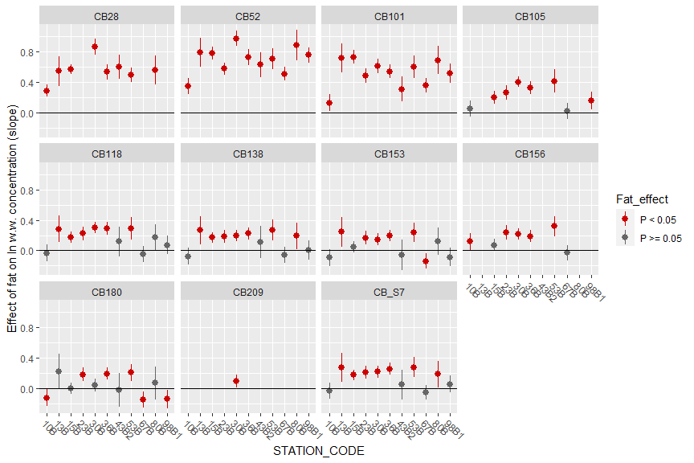

### BDEs

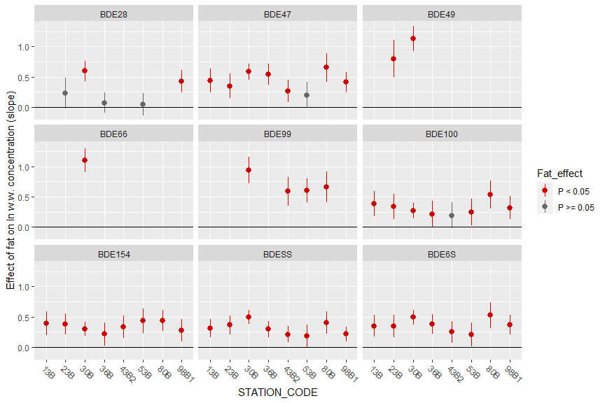

### Organochorines, paraffins

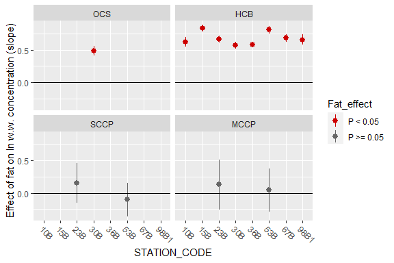

### PFAS and DDTs

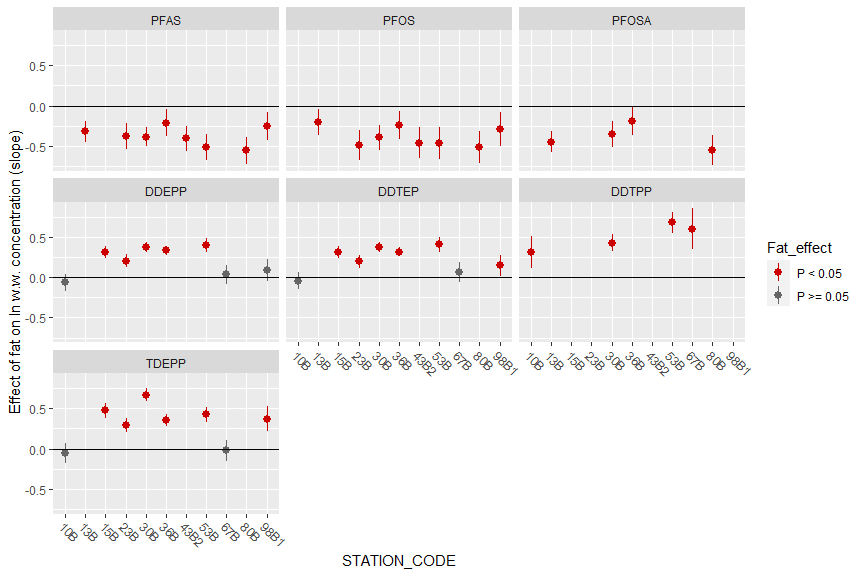

## Effect of fat, explained variance

### PCBs

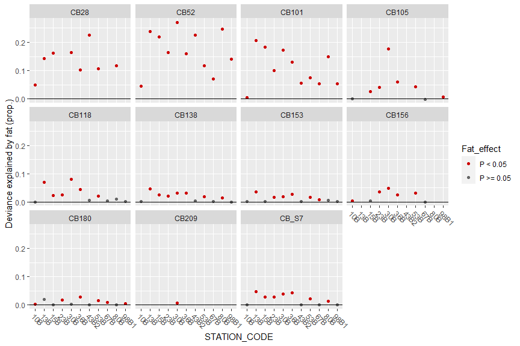

### BDEss

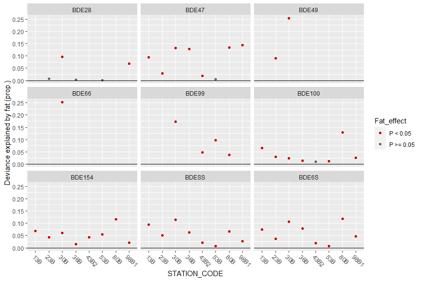

### Organochorines, paraffins

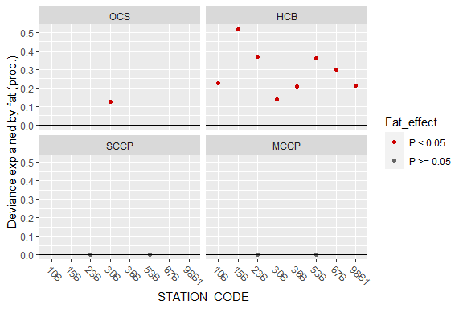

### PFAS and DDTs

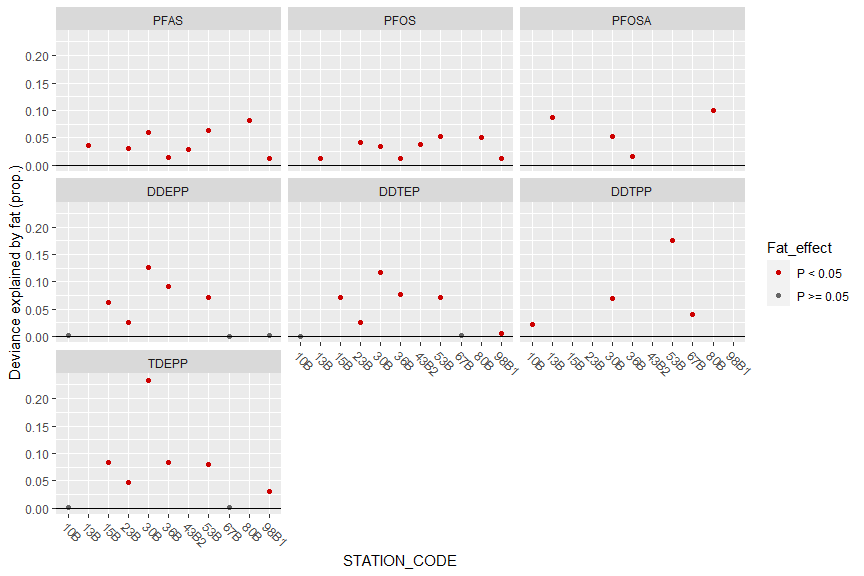

## Some more examples

In all figures, the y axis is the expected w.w. concentration (given all aother variables are at mean value), and the x axes are  
* MYEAR = measurement year  
* FAT_PERC = fat percentage in tissue  
* LNMEA = length of fish in millimeters

### CB52 at station 36B

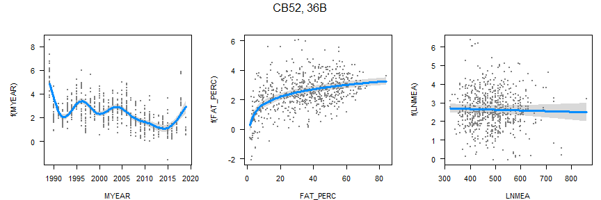

### CB118 at station 36B

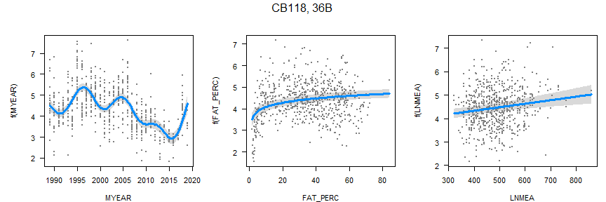

### CB_S7 at station 36B

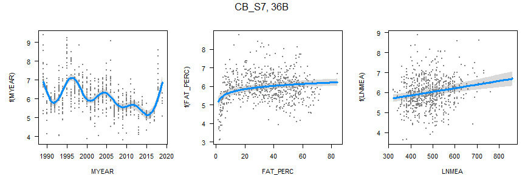

### BDE49 at station 30B

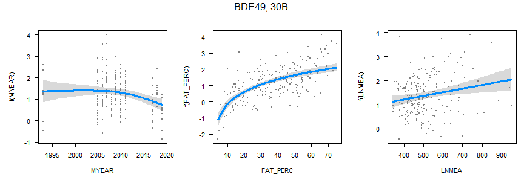

### BDE99 at station 30B

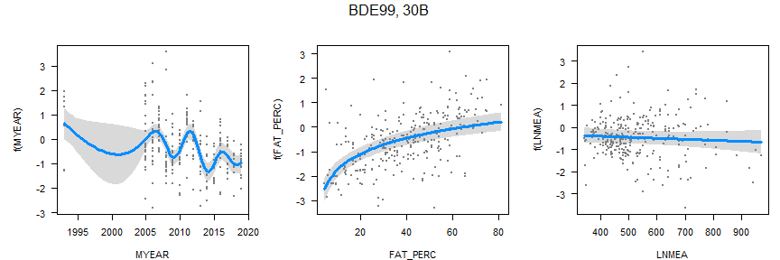

### BDE6S at station 30B

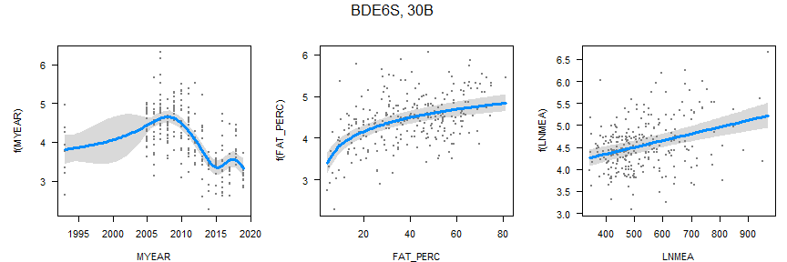

### OCS at station 30B

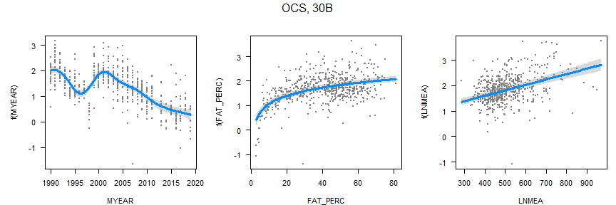

### HCB at station 23B

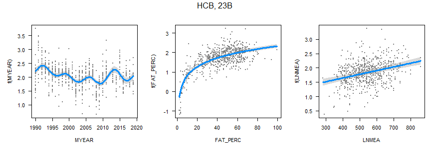

### SCCP at station 23B

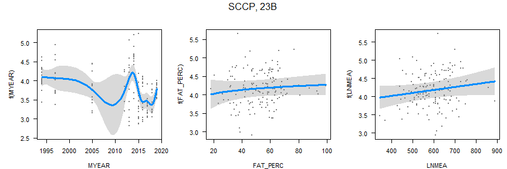

### PFOS at station 30B

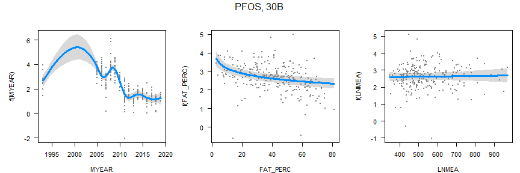

### DDEPP at station 30B

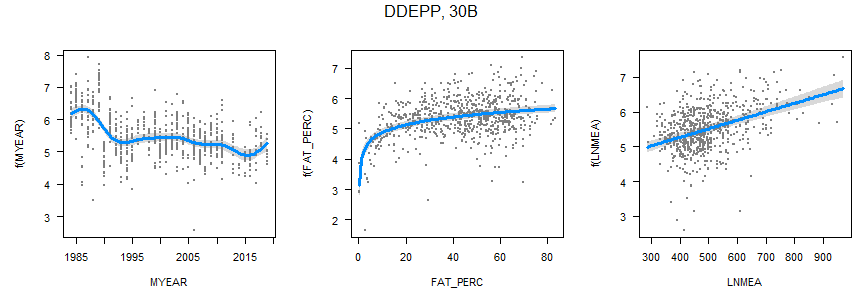